# Untitled

B082040005 高念慈

2023-01-03

```r
# str(df)
dat = KH[,-c("Transfer_area_land","Transfer_area_building")]
colnames(dat)
```

```
##  [1] "X"                              "Y"
##  [3] "Location_TownID"                "TradeYear"
##  [5] "TradeYQ"                        "TdSeason"
##  [7] "TradeYM"                        "TradeYMD"
##  [9] "Price_total"                    "Type_parking_space"
## [11] "Type_land"                      "Type_building_without_PS"
## [13] "Type_building_with_PS"          "Type_building_price_inclued_PS"
## [15] "Parking_space_total_area"       "Parking_space_price"
## [17] "Using_type_L"                   "Using_type_B"
## [19] "Using_type_Far"                 "Using_type_Fac"
## [21] "Using_type_O"                   "Land_usage_city"
## [23] "Land_usage_nonecity"            "Land_usage_mt_preservation"
## [25] "Build_Y"                        "Build_YM"
## [27] "Build_YMD"                      "Building_age"
## [29] "Building_Apt_general"           "Building_Apt_luxury"
## [31] "Building_Apt_WS"                "Building_House"
## [33] "Building_Suit"                  "Building_Others"
## [35] "Floor_transfer"                 "Floor_complex"
## [37] "Floor_nodata"                   "TtFloor"
## [39] "TtFloor_nodata"                 "Pattern_room"
## [41] "Pattern_room_nodata"            "Pattern_hall"
## [43] "Pattern_hall_nodata"            "Pattern_bath"
## [45] "Pattern_bath_nodata"            "Pattern_non"
## [47] "NoManageOrg"                    "MRTin500"
## [49] "Location_Income"                "d_mountain"
## [51] "distance_factory"               "distance_airport"
## [53] "distance_interchange"           "distance_train"
## [55] "distance_LRT"                   "temple_distant"
## [57] "temple_distant_200"             "temple_distant_350"
## [59] "temple_distant_500"
```

### 資料

- 目標變數 : “Price_total”，交易總價(萬)

### 主要關心變數

- “temple_distant”
- “temple_distant_200”
- “temple_distant_350”
- “temple_distant_500”

### 切資料

```r
# Split dataset training (70%) and testing (30%)

set.seed(1)
train_idx <- sample(1:nrow(dat), nrow(dat) * 0.7)
train <- dat[train_idx, ]
test <-  dat[setdiff(1:nrow(dat), train_idx),]

train_y = train[, c("Price_total")]
test_y = test[ , c("Price_total")]
```

```r
train[, c("Price_total")] = (log(train[, c("Price_total")]))
test[, c("Price_total")] = (log(test[ , c("Price_total")]))

train = train[is.finite(train$Price_total),] # 去掉 inf NA NAN
test = test[is.finite(test$Price_total),] # 去掉 inf NA NAN

train_y = train[, c("Price_total")]
test_y = test[ , c("Price_total")]
```

### model

```r
# install.packages("xgboost")
library(xgboost)
```

- subsample = bag.fraction參數
- nfold: 將投入的data參數值（在此處為訓練資料集），隨機切割(partition)為n等分的子樣本
- eta: learning rate,學習步伐(default為0.3)
- nrounds: 模型所使用的樹個數(迭代數)
- nthread = 2：我們將要使用的 CPU 線程數

```r
starttime =  now()

model_gbm <- xgboost(data = as.matrix(train[,c(1:8,10:59)]),
                     label = (as.matrix(train[,c(9)])),
                     max.depth = 6,
                     eta = 0.1,
                     nthread = 2,
                     nfold = 5,
                     nrounds = 100,
                     subsample = 0.6,
                     objective = "reg:linear",
                     verbose = 0)
```

[output not shown]

```r
endtime = now()

print(endtime - starttime)
```

```
## Time difference of 9.674901 secs
```

```r
print(model_gbm)
```

```
## ##### xgb.Booster
## raw: 347.7 Kb
## call:
##   xgb.train(params = params, data = dtrain, nrounds = nrounds,
##     watchlist = watchlist, verbose = verbose, print_every_n = print_every_n,
##     early_stopping_rounds = early_stopping_rounds, maximize = maximize,
##     save_period = save_period, save_name = save_name, xgb_model = xgb_model,
##     callbacks = callbacks, max.depth = 6, eta = 0.1, nthread = 2,
##     nfold = 5, subsample = 0.6, objective = "reg:linear")
## params (as set within xgb.train):
##   max_depth = "6", eta = "0.1", nthread = "2", nfold = "5", subsample = "0.6", objective = "reg:linear", validate_parameters = "TRUE"
## xgb.attributes:
##   niter
## callbacks:
##   cb.evaluation.log()
## # of features: 58
## niter: 100
## nfeatures : 58
## evaluation_log:
##     iter train_rmse
##        1  5.3251021
##        2  4.7982294
## ---
##       99  0.3495572
##      100  0.3490682
```

### 預測

```r
pred_y = predict(model_gbm, newdata = as.matrix(test[,c(1:8,10:59)]))

#########################

train_pred_y = predict(model_gbm, as.matrix(train[,c(1:8,10:59)]))
```

```r
RSQUARE = function(y_actual,y_predict){
  cor(y_actual,y_predict)^2
}

a = RSQUARE(unlist((test_y)) , pred_y)
cat('The R-square of the test data is ', round(a,3), '\n')
```

```
## The R-square of the test data is  0.785
```

```r
b = RSQUARE(unlist((train_y)) , train_pred_y)
cat('The R-square of the train data is ', round(b,3), '\n')
```

```
## The R-square of the train data is  0.836
```

- The root mean square error of the test data is 0.398
- The R-square of the test data is 0.785
- The root mean square error of the train data is 0.398
- The R-square of the train data is 0.835

```r
residuals = (test_y) - pred_y
RMSE = sqrt(mean(unlist(residuals^2)))
cat('The root mean square error of the test data is ', round(RMSE,3),'\n')
```

```
## The root mean square error of the test data is  0.398
```

```r
y_test_mean = mean(unlist((test_y)))
# Calculate total sum of squares
tss =  sum((unlist((test_y)) - y_test_mean)^2 )
# Calculate residual sum of squares
rss =  sum(residuals^2)
# Calculate R-squared
rsq  =  1 - (rss/tss)
cat('The R-square of the test data is ', round(rsq,3), '\n')
```

```
## The R-square of the test data is  0.785
```

```r
##############################################

train_residuals = (train_y) - train_pred_y
train_RMSE = sqrt(mean(unlist(train_residuals^2)))
cat('The root mean square error of the train data is ', round(RMSE,3),'\n')
```

```
## The root mean square error of the train data is  0.398
```

```r
y_train_mean = mean(unlist((train_y)))
# Calculate total sum of squares
tss =  sum((unlist((train_y)) - y_train_mean)^2 )
# Calculate residual sum of squares
rss =  sum(train_residuals^2)
# Calculate R-squared
rsq  =  1 - (rss/tss)
cat('The R-square of the train data is ', round(rsq,3), '\n')
```

```
## The R-square of the train data is  0.835
```

- 22. temple_distant 0.0100343929
- 45. temple_distant_500 0.0002115829
- 49. temple_distant_350 0.0001322594
- 50後 temple_distant_200

```r
importance_matrix <- xgb.importance(model = model_gbm)
print(importance_matrix)
```

```
##                            Feature         Gain        Cover    Frequency
##  1:                      Build_YMD 0.2258222217 6.404863e-02 0.0206730769
##  2:                   Pattern_room 0.1018977136 8.142765e-02 0.0548076923
##  3:                   Pattern_bath 0.0891295174 5.674391e-02 0.0358173077
##  4:                   Building_age 0.0596518546 7.301646e-02 0.0430288462
##  5:                 Floor_transfer 0.0578645823 5.701518e-02 0.0353365385
##  6:                   distance_LRT 0.0446272077 4.899373e-02 0.0550480769
##  7:          Type_building_with_PS 0.0423357380 1.259680e-02 0.0072115385
##  8:                        Build_Y 0.0414990753 5.272772e-03 0.0228365385
##  9:                        TtFloor 0.0379338916 5.645467e-02 0.0427884615
## 10:                  Building_Suit 0.0339200928 7.816807e-03 0.0079326923
## 11:       Parking_space_total_area 0.0258267261 3.597363e-02 0.0177884615
## 12:                Building_Others 0.0238433240 2.530836e-02 0.0141826923
## 13:                Location_Income 0.0238195004 3.736435e-02 0.0442307692
## 14:                              X 0.0193452679 7.700835e-02 0.1187500000
```

[output cut: 37 more lines]

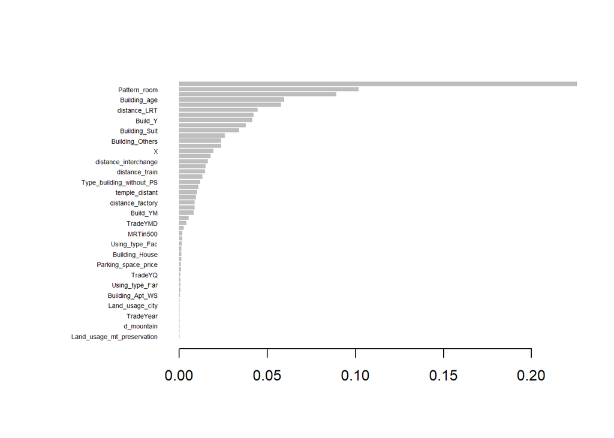

```r
xgb.plot.importance(importance_matrix = importance_matrix)
```

- https://blog.csdn.net/langyichao1/article/details/70175715
- 變數重要性圖

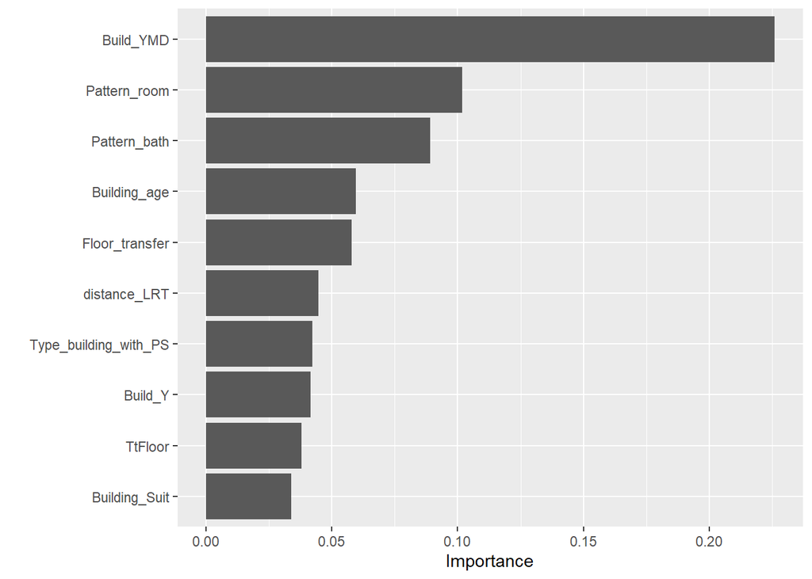

```r
# install.packages('vip')
vip::vip(model_gbm)
```

- 大概25棵就收斂了

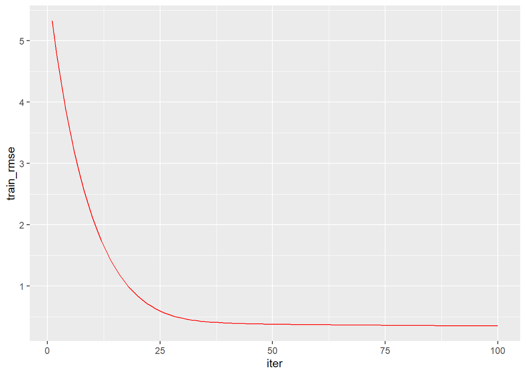

```r
# plot error vs number trees
ggplot(model_gbm$evaluation_log) +
  geom_line(aes(iter, train_rmse), color = "red")
```

```r
#+
  geom_line(aes(iter, test_rmse_mean), color = "blue")
```

```
## mapping: x = ~iter, y = ~test_rmse_mean
## geom_line: na.rm = FALSE, orientation = NA
## stat_identity: na.rm = FALSE
## position_identity
```

### 刪變數取重要性 前30

```r
# importance_matrix$Feature

train = train[,c("Build_YMD", "Pattern_room", "Pattern_bath", "Building_age",
                 "Floor_transfer", "distance_LRT", "Type_building_with_PS", "Build_Y",
                 "TtFloor", "Building_Suit", "Parking_space_total_area", "Building_Others",
                 "Location_Income", "X", "Building_Apt_general", "distance_interchange",
                 "Pattern_hall", "distance_train", "Location_TownID", "Type_building_without_PS",
                 "Y", "temple_distant", "distance_airport", "distance_factory", "Type_parking_space",
                 "Build_YM", "Pattern_non", "TradeYMD", "Using_type_B", "MRTin500", "Price_total")]


test = test[,c("Build_YMD", "Pattern_room", "Pattern_bath", "Building_age",
                 "Floor_transfer", "distance_LRT", "Type_building_with_PS", "Build_Y",
                 "TtFloor", "Building_Suit", "Parking_space_total_area", "Building_Others",
                 "Location_Income", "X", "Building_Apt_general", "distance_interchange",
                 "Pattern_hall", "distance_train", "Location_TownID", "Type_building_without_PS",
                 "Y", "temple_distant", "distance_airport", "distance_factory", "Type_parking_space",
                 "Build_YM", "Pattern_non", "TradeYMD", "Using_type_B", "MRTin500", "Price_total")]
```

## 調參

- eta : 控制學習步伐
- max_depth: 樹的深度
- min_child_weight: 末梢節點的最小觀測值個數
- subsample: 每棵樹模型所抽樣訓練資料集的比例
- colsample_bytrees: 每棵樹模型所抽樣的欄位數目

```r
model_gbm <- xgboost(data = as.matrix(train[,c(1:30)]),
                     label = (as.matrix(train[,c(31)])),
                     max.depth = 6,
                     eta = 0.01,
                     nthread = 2,
                     nfold = 5,
                     nrounds = 1000,
                     subsample = 0.6,
                     objective = "reg:linear",
                     verbose = 0)
```

[output not shown]

### 預測

```r
pred_y = predict(model_gbm, newdata = as.matrix(test[,c(1:30)]))

#########################

train_pred_y = predict(model_gbm, as.matrix(train[,c(1:30)]))
```

- The root mean square error of the test data is 0.398
- The R-square of the test data is 0.785
- The root mean square error of the train data is 0.398
- The R-square of the train data is 0.835
- The root mean square error of the test data is 0.395
- The R-square of the test data is 0.788
- The root mean square error of the train data is 0.395
- The R-square of the train data is 0.839

```r
residuals = (test_y) - pred_y
RMSE = sqrt(mean(unlist(residuals^2)))
cat('The root mean square error of the test data is ', round(RMSE,3),'\n')
```

```
## The root mean square error of the test data is  0.395
```

```r
y_test_mean = mean(unlist((test_y)))
# Calculate total sum of squares
tss =  sum((unlist((test_y)) - y_test_mean)^2 )
# Calculate residual sum of squares
rss =  sum(residuals^2)
# Calculate R-squared
rsq  =  1 - (rss/tss)
cat('The R-square of the test data is ', round(rsq,3), '\n')
```

```
## The R-square of the test data is  0.788
```

```r
##############################################

train_residuals = (train_y) - train_pred_y
train_RMSE = sqrt(mean(unlist(train_residuals^2)))
cat('The root mean square error of the train data is ', round(RMSE,3),'\n')
```

```
## The root mean square error of the train data is  0.395
```

```r
y_train_mean = mean(unlist((train_y)))
# Calculate total sum of squares
tss =  sum((unlist((train_y)) - y_train_mean)^2 )
# Calculate residual sum of squares
rss =  sum(train_residuals^2)
# Calculate R-squared
rsq  =  1 - (rss/tss)
cat('The R-square of the train data is ', round(rsq,3), '\n')
```

```
## The R-square of the train data is  0.839
```

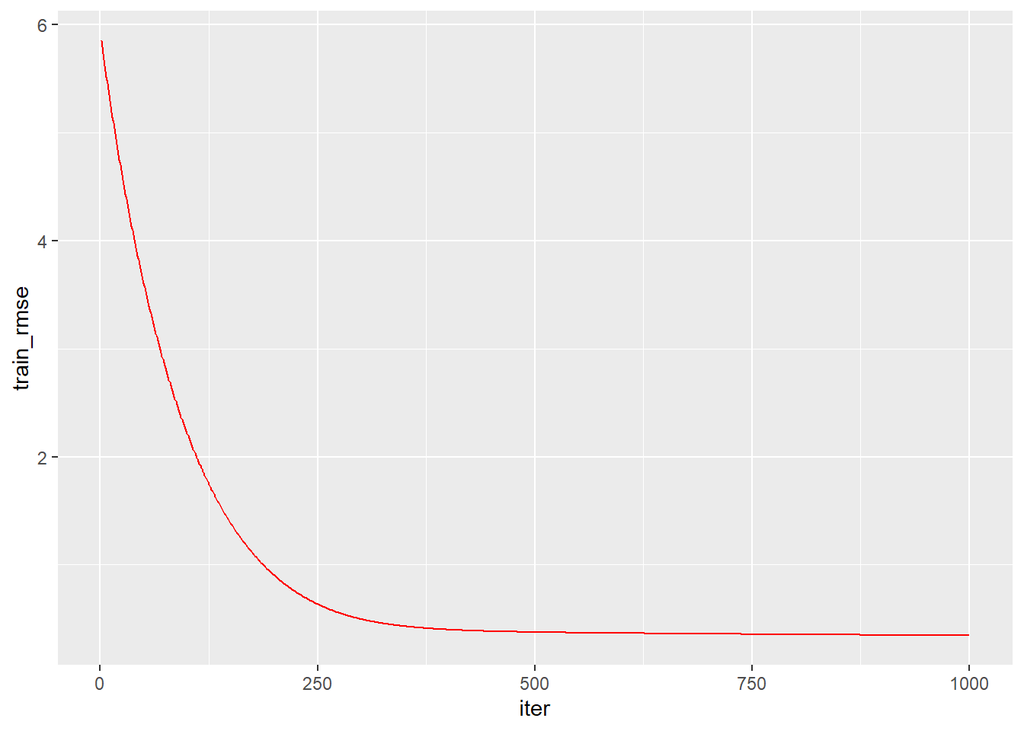

```r
# plot error vs number trees
ggplot(model_gbm$evaluation_log) +
  geom_line(aes(iter, train_rmse), color = "red")
```

```r
#+
  geom_line(aes(iter, test_rmse_mean), color = "blue")
```

```
## mapping: x = ~iter, y = ~test_rmse_mean
## geom_line: na.rm = FALSE, orientation = NA
## stat_identity: na.rm = FALSE
## position_identity
```

```r
importance_matrix <- xgb.importance(model = model_gbm)
print(importance_matrix)
```

```
##                      Feature        Gain       Cover   Frequency
##  1:                Build_YMD 0.291750661 0.101717447 0.118101445
##  2:             Pattern_room 0.101649562 0.080567330 0.062069908
##  3:             Pattern_bath 0.086907741 0.057805996 0.040468487
##  4:           Floor_transfer 0.058250252 0.071954245 0.043954792
##  5:             distance_LRT 0.048940174 0.059437102 0.084514424
##  6:             Building_age 0.047366109 0.076795259 0.054094700
##  7:    Type_building_with_PS 0.041147377 0.013160152 0.009068951
##  8:                  TtFloor 0.040978143 0.053895866 0.047372738
##  9:            Building_Suit 0.036629665 0.007965721 0.007610628
## 10:          Building_Others 0.026092210 0.024860257 0.016064349
## 11: Parking_space_total_area 0.024493430 0.031769347 0.019322791
## 12:          Location_Income 0.024220311 0.041097373 0.050061523
## 13:                        X 0.019592595 0.078401068 0.066946179
## 14:     distance_interchange 0.016883019 0.019538140 0.041516657
## 15:     Building_Apt_general 0.015763355 0.010698414 0.006516885
## 16:           distance_train 0.014553726 0.028695550 0.051041334
## 17:             Pattern_hall 0.014471980 0.041105821 0.023743335
## 18:          Location_TownID 0.012018708 0.023855264 0.020803901
## 19: Type_building_without_PS 0.011708744 0.008897207 0.015608622
## 20:         distance_factory 0.010723615 0.031701225 0.038805086
## 21:         distance_airport 0.010283639 0.035596850 0.037118899
## 22:           temple_distant 0.010107012 0.022944657 0.051702137
## 23:              Pattern_non 0.009504009 0.003745611 0.004534476
## 24:                        Y 0.008222196 0.038328370 0.034133892
## 25:       Type_parking_space 0.007625686 0.010205767 0.008317003
## 26:                 TradeYMD 0.005372001 0.012737948 0.036799891
## 27:             Using_type_B 0.003139045 0.002340425 0.005058561
## 28:                 MRTin500 0.001605036 0.010181587 0.004648407
##                      Feature        Gain       Cover   Frequency
```

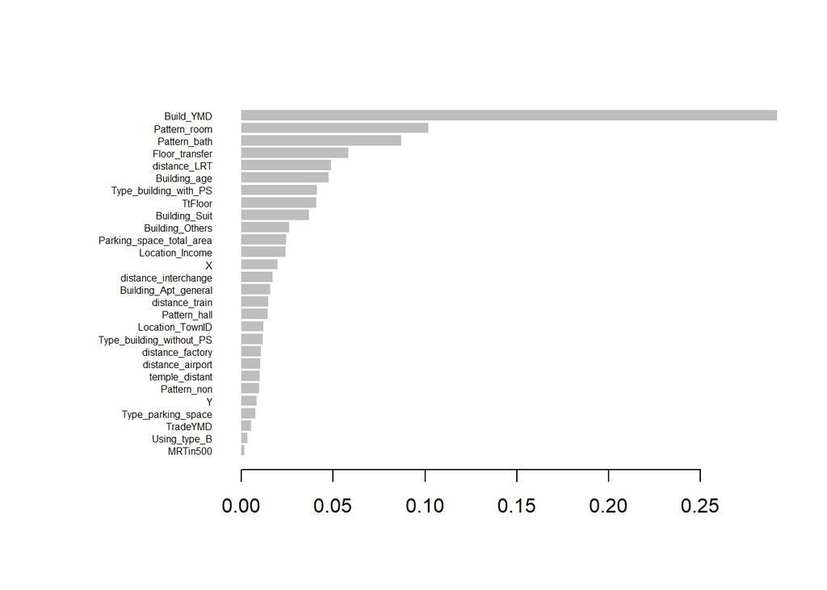

```r
xgb.plot.importance(importance_matrix = importance_matrix)
```